# Final example

Let’s work through a sports example since it’s March Madness and my bracket is already busted.

Background: I went to Marquette Univeristy and my Freshman year was Jimmy Butler’s final season (the 2010-11 season was awesome!)

So this is the data we’ll work with:

Some of this example will work through this template from Matt Waite at NICAR 2019: https://mattwaite.github.io/nicar19/CourseMaterials.html

- data: [All team game logs for the 2018-19 season](https://github.com/mattwaite/NICAR19SportsDataViz)

*All datasets sourced from Sports Reference.*

Marquette data for the 2010-2011 season:

- College basketball gamelogs for [Marquette University’s 2010-11 season](https://www.sports-reference.com/cbb/schools/marquette/2011-gamelogs.html).

And the game logs for each individual player: + [Darius Johson-Odom](https://www.sports-reference.com/cbb/players/darius-johnson-odom-1/gamelog/2011) + [Jimmy Butler](https://www.sports-reference.com/cbb/players/jimmy-butler-1/gamelog/2011) + [Jae Crowder](https://www.sports-reference.com/cbb/players/jae-crowder-1/gamelog/2011) + [Dwight Buycks](https://www.sports-reference.com/cbb/players/dwight-buycks-1/gamelog/2011) + [Chris Otule](https://www.sports-reference.com/cbb/players/chris-otule-1/gamelog/2011) + [Vander Blue](https://www.sports-reference.com/cbb/players/vander-blue-1/gamelog/2011) + [Davante Gardner](https://www.sports-reference.com/cbb/players/davante-gardner-1/gamelog/2011) + [Junior Cadougan](https://www.sports-reference.com/cbb/players/junior-cadougan-1/gamelog/2011) + [Joe Fulce](https://www.sports-reference.com/cbb/players/joe-fulce-1/gamelog/2011) + [Erik Williams](https://www.sports-reference.com/cbb/players/erik-williams-1/gamelog/2011) + [Jamail Jones](https://www.sports-reference.com/cbb/players/jamail-jones-1/gamelog/2011) + [Reggie Smith](https://www.sports-reference.com/cbb/players/reggie-smith-1/gamelog/2011) + [Robert Frozena](https://www.sports-reference.com/cbb/players/robert-frozena-1/gamelog/2011)

## Goal

Clean, analyze and visualize these datasets. To do that we’ll work with R’s tidyverse library.

```r
#uncomment and run install code if tidyverse is not already running
#install.packages("tidyverse")
library(tidyverse)
# optional library but could be useful for plotting
#install.packages("lubridate") #helps us reformat the date column
library(lubridate)
```

## Clean

We’re going to load this and forget about it for a minute because Matt Waite did the dirty work of cleaning this for us already!

```r
all_teams <- read_csv("data/1819-all-logs.csv")
```

```r
logs <- read_csv("data/mu-11-12-gamelog.csv", skip=1)
# we use skip = 1 becuase there is an extra row of label data that we don't need.
colnames(logs)
```

```
 [1] "G"     "Date"  "X3"    "Opp"   "W/L"   "Tm"    "Opp_1" "FG"    "FGA"   "FG%"   "3P"    "3PA"   "3P%"   "FT"    "FTA"
[16] "FT%"   "ORB"   "TRB"   "AST"   "STL"   "BLK"   "TOV"   "PF"    "X24"   "FG_1"  "FGA_1" "FG%_1" "3P_1"  "3PA_1" "3P%_1"
[31] "FT_1"  "FTA_1" "FT%_1" "ORB_1" "TRB_1" "AST_1" "STL_1" "BLK_1" "TOV_1" "PF_1"
```

```r
# create a new dataframe 'cleaned_logs' here and rename each column, separate by comma
# rename(dataframe, new_name = old_name, new_name = old_name, new_name = old_name...)
clean_logs <-
  rename(logs, game = G, date = Date, home_away = X3, opponent = Opp, w_l = `W/L`, team_score = Tm, opponent_score = Opp_1, team_FG = FG, team_FGA = FGA, team_FGpct = `FG%`, team_3P = `3P`, team_3PA = `3PA`, team_3Ppct = `3P%`, team_FT = FT, team_FTpct = `FT%`, team_ORB = ORB, team_TRB = TRB, team_AST = AST, team_STL = STL, team_BLK = BLK, team_TOV = TOV, team_PF = PF, opponent_FG = FG_1, opponent_FGA = FGA_1, opponent_FGpct = `FG%_1`, opponent_3P = `3P_1`, opponent_3PA = `3PA_1`, opponent_3Ppct = `3P%_1`, opponent_FT = FT_1, opponent_FTpct = `FT%_1`, opponent_ORB = ORB_1, opponent_TRB = TRB_1, opponent_AST = AST_1, opponent_STL = STL_1, opponent_BLK = BLK_1, opponent_TOV = TOV_1, opponent_PF = PF_1)
# remove the blank separater column and reassign to clean_logs
clean_logs <- clean_logs %>% select(-X24)
```

Now let’s combine and clean each of the players gamelog data from Marquette University’s 2010-11 roster:

```r
# run each group of functions separately

odom <- read_csv("mu-players/djo-1011.csv")
butler <- read_csv("mu-players/jbutler-1011.csv")
crowder <- read_csv("mu-players/crowder-1011.csv")
buycks <- read_csv("mu-players/buycks-1011.csv")
otule <- read_csv("mu-players/otule-1011.csv")
blue <- read_csv("mu-players/blue-1011.csv")
gardner <- read_csv("mu-players/gardner-1011.csv")
cadougan <- read_csv("mu-players/cadougan-1011.csv")
fulce <- read_csv("mu-players/fulce-1011.csv")
williams <- read_csv("mu-players/williams-1011.csv")
jones <- read_csv("mu-players/jones-1011.csv")
smith <- read_csv("mu-players/smith-1011.csv")
frozena <- read_csv("mu-players/frozena-1011.csv")

# add a column for the players name to join easier
odom$player <- "Darius Johnson-Odom"
butler$player <- "Jimmy Butler"
crowder$player <- "Jae Crowder"
buycks$player <- "Dwight Buycks"
otule$player <- "Chris Otule"
blue$player <- "Vander Blue"
gardner$player <- "Davante Gardner"
cadougan$player <- "Junior Cadougan"
fulce$player <- "Joe Fulce"
williams$player <- "Erik Williams"
jones$player <- "Jamail Jones"
smith$player <- "Reggie Smith"
frozena$player <- "Robert Frozena"

#TIP: can re-export a csv updated with name column to replace current one if needed
#write_csv(odom, "mu-players/djo-1011.csv")

mu_players <- merge(odom, butler, all=TRUE) %>%
  merge(., crowder, all = TRUE) %>%
  merge(., buycks, all = TRUE) %>%
  merge(., otule, all = TRUE) %>%
  merge(., blue, all = TRUE) %>%
  merge(., gardner, all = TRUE) %>%
  merge(., cadougan, all = TRUE) %>%
  merge(., fulce, all = TRUE) %>%
  merge(., williams, all = TRUE) %>%
  merge(., jones, all = TRUE) %>%
  merge(., smith, all = TRUE) %>%
  merge(., frozena, all = TRUE)

# rename some columns and filter out each player's overall season row at the bottom
# but before we remove overall season totals let's bring those into a separate table for some analysis
player_totals <- mu_players %>% filter(is.na(Rk)) %>% rename(total_games = Date)
player_totals <- select(player_totals, -c(1, 3:7))

mu_players <- mu_players %>% rename(game = Rk, date = Date, opponent = Opponent, type = Type, home_away = X4, win_loss = X7) %>% filter(., !is.na(game))

# Let's export the mu_players csv to save our cleaning.
write_csv(mu_players, "mu-players/all.csv")
```

## Analyze

First, let’s look at the score differential.

The `%>%` is the pipe symbol. It help you apply multiple commands to the same dataframe by stringing them together

Here we do some math by adding a new column with `mutate()` called “differential” to show how much the team wins or loses by. And then sort that column in decending order. `arrange()` is `dplyr` version of sort

```r
clean_logs %>%
  mutate(differential = team_score-opponent_score) %>%
  arrange(desc(differential)) -> arranged_logs
```

Next, let’s compare player’s overall totals throughout the season.

This is why I used `filter()` to grab the final row of each player’s gamelogs. It includes the cummulative stats for the amount of games each Marquette team member played throughout the 2010-11 season.

An obvious assumption is that the more games you play the higher totals and season averages a player will have. We can use the `arrange()` function to check that correlation.

```r
arrange(player_totals, desc(PTS))
```

| total_games | GS | MP | FG | FGA | FG% | 2P | 2PA | 2P% | 3P | 3PA | 3P% | FT | FTA | FT% | ORB | DRB | TRB | AST | STL | BLK | TOV | PF | PTS | player |
| --- | --- | --- | --- | --- | --- | --- | --- | --- | --- | --- | --- | --- | --- | --- | --- | --- | --- | --- | --- | --- | --- | --- | --- | --- |
| 37 Games | 35 | 1109 | 196 | 453 | 0.433 | 125 | 258 | 0.484 | 71 | 195 | 0.364 | 121 | 171 | 0.708 | 18 | 94 | 112 | 88 | 31 | 7 | 75 | 92 | 584 | Darius Johnson-Odom |
| 37 Games | 35 | 1282 | 187 | 382 | 0.490 | 167 | 324 | 0.515 | 20 | 58 | 0.345 | 188 | 240 | 0.783 | 90 | 135 | 225 | 86 | 53 | 13 | 54 | 49 | 582 | Jimmy Butler |
| 37 Games | 17 | 1021 | 158 | 326 | 0.485 | 116 | 209 | 0.555 | 42 | 117 | 0.359 | 77 | 125 | 0.616 | 83 | 168 | 251 | 58 | 48 | 32 | 30 | 85 | 435 | Jae Crowder |
| 36 Games | 29 | 1013 | 117 | 254 | 0.461 | 78 | 159 | 0.491 | 39 | 95 | 0.411 | 45 | 66 | 0.682 | 25 | 86 | 111 | 121 | 38 | 2 | 84 | 55 | 318 | Dwight Buycks |
| 37 Games | 35 | 651 | 73 | 132 | 0.553 | 73 | 132 | 0.553 | 0 | 0 | NA | 42 | 72 | 0.583 | 58 | 76 | 134 | 5 | 11 | 55 | 39 | 100 | 188 | Chris Otule |
| 37 Games | 12 | 703 | 69 | 175 | 0.394 | 65 | 150 | 0.433 | 4 | 25 | 0.16 | 45 | 74 | 0.608 | 31 | 73 | 104 | 59 | 33 | 8 | 51 | 66 | 187 | Vander Blue |
| 33 Games | 0 | 296 | 53 | 92 | 0.576 | 53 | 92 | 0.576 | 0 | 0 | NA | 46 | 61 | 0.754 | 35 | 38 | 73 | 10 | 4 | 5 | 20 | 45 | 152 | Davante Gardner |
| 36 Games | 5 | 712 | 46 | 109 | 0.422 | 44 | 96 | 0.458 | 2 | 13 | 0.154 | 51 | 80 | 0.638 | 11 | 55 | 66 | 115 | 20 | 2 | 58 | 63 | 145 | Junior Cadougan |
| 29 Games | 1 | 255 | 36 | 75 | 0.480 | 29 | 55 | 0.527 | 7 | 20 | 0.35 | 13 | 13 | 1.000 | 15 | 46 | 61 | 12 | 7 | 7 | 6 | 34 | 92 | Joe Fulce |
| 24 Games | 11 | 168 | 23 | 48 | 0.479 | 23 | 46 | 0.500 | 0 | 2 | 0 | 7 | 10 | 0.700 | 17 | 21 | 38 | 3 | 4 | 0 | 8 | 16 | 53 | Erik Williams |

[output cut: 3 more lines]

```r
# now replace "PTS" above with any of the other column names like AST, BLK, 3P, etc.
# remember if you try and arrange by any of the columns that start with a number you need to use backticks (ex: `3P`) so R will understand.
```

Becasue we kept each individual player’s data we can run some comparisons between teammates throughout the season too.

For example let’s just use `arrange` again see who scored the most points per game throughout the season.

```r
arrange(mu_players, desc(PTS))
```

| game | date | School | home_away | opponent | type | win_loss | GS | MP | FG | FGA | FG% | 2P | 2PA | 2P% | 3P | 3PA | 3P% | FT | FTA | FT% | ORB | DRB | TRB | AST | STL | BLK | TOV | PF | PTS | … |
| --- | --- | --- | --- | --- | --- | --- | --- | --- | --- | --- | --- | --- | --- | --- | --- | --- | --- | --- | --- | --- | --- | --- | --- | --- | --- | --- | --- | --- | --- | --- |
| 30 | 2011-03-02 | Marquette | NA | Cincinnati | REG | L | 1 | 39 | 7 | 15 | 0.467 | 6 | 12 | 0.500 | 1 | 3 | 0.333 | 15 | 17 | 0.882 | 3 | 3 | 6 | 0 | 3 | 0 | 1 | 2 | 30 | … |
| 7 | 2010-11-27 | Marquette | @ | Milwaukee | REG | W | 1 | 35 | 10 | 14 | 0.714 | 5 | 7 | 0.714 | 5 | 7 | 0.714 | 4 | 4 | 1.000 | 0 | 4 | 4 | 3 | 0 | 0 | 1 | 2 | 29 | … |
| 14 | 2011-01-01 | Marquette | NA | West Virginia | REG | W | 1 | 39 | 12 | 14 | 0.857 | 10 | 10 | 1.000 | 2 | 4 | 0.5 | 3 | 5 | 0.600 | 5 | 3 | 8 | 5 | 4 | 1 | 1 | 1 | 29 | … |
| 15 | 2011-01-05 | Marquette | @ | Rutgers | REG | W | 1 | 36 | 9 | 14 | 0.643 | 4 | 6 | 0.667 | 5 | 8 | 0.625 | 6 | 8 | 0.750 | 0 | 0 | 0 | 2 | 0 | 1 | 3 | 1 | 29 | … |
| 20 | 2011-01-22 | Marquette | @ | Notre Dame | REG | L | 1 | 33 | 6 | 14 | 0.429 | 4 | 7 | 0.571 | 2 | 7 | 0.286 | 11 | 13 | 0.846 | 0 | 1 | 1 | 4 | 0 | 0 | 1 | 3 | 25 | … |
| 22 | 2011-01-29 | Marquette | NA | Syracuse | REG | W | 1 | 36 | 8 | 16 | 0.500 | 7 | 13 | 0.538 | 1 | 3 | 0.333 | 8 | 10 | 0.800 | 1 | 6 | 7 | 1 | 1 | 1 | 0 | 1 | 25 | … |
| 26 | 2011-02-15 | Marquette | NA | St. John's (NY) | REG | L | 1 | 36 | 9 | 13 | 0.692 | 9 | 11 | 0.818 | 0 | 2 | 0 | 5 | 7 | 0.714 | 1 | 6 | 7 | 2 | 0 | 0 | 3 | 2 | 23 | … |
| 32 | 2011-03-08 | Marquette | N | Providence | CTOURN | W | 1 | 32 | 9 | 17 | 0.529 | 6 | 11 | 0.545 | 3 | 6 | 0.5 | 2 | 2 | 1.000 | 1 | 4 | 5 | 1 | 1 | 0 | 1 | 0 | 23 | … |
| 5 | 2010-11-22 | Marquette | N | Duke | REG | L | 1 | 38 | 9 | 19 | 0.474 | 9 | 17 | 0.529 | 0 | 2 | 0 | 4 | 6 | 0.667 | 1 | 5 | 6 | 1 | 2 | 0 | 2 | 3 | 22 | … |
| 6 | 2010-11-23 | Marquette | N | Gonzaga | REG | L | 1 | 38 | 7 | 13 | 0.538 | 5 | 8 | 0.625 | 2 | 5 | 0.4 | 6 | 9 | 0.667 | 2 | 4 | 6 | 1 | 0 | 0 | 0 | 2 | 22 | … |

[output cut: 373 more lines]

```r
# this shows Jimmy Butler, Darius Johnson-Odom and Jae Crowder had some of the highest points per game
```

We can also use filter to see how many players scored above double digits in a game. Remember we have 383 rows of data.

```r
more_than_ten <- filter(mu_players, PTS >= 10) %>% arrange(., desc(PTS))
```

This table shows 133 rows or *records* of instances where Marquette players scored more greater than or equal to 10 points during a game

If you scan through you can see Darius Johnson-Odom scored over 10 points per game A LOT.

Let’s go one step further and find the average amount of games DJO scored over 10 points in a game.

```r
filter(more_than_ten, player == "Darius Johnson-Odom")
```

| game | date | School | home_away | opponent | type | win_loss | GS | MP | FG | FGA | FG% | 2P | 2PA | 2P% | 3P | 3PA | 3P% | FT | FTA | FT% | ORB | DRB | TRB | AST | STL | BLK | TOV | PF | PTS | … |
| --- | --- | --- | --- | --- | --- | --- | --- | --- | --- | --- | --- | --- | --- | --- | --- | --- | --- | --- | --- | --- | --- | --- | --- | --- | --- | --- | --- | --- | --- | --- |
| 7 | 2010-11-27 | Marquette | @ | Milwaukee | REG | W | 1 | 35 | 10 | 14 | 0.714 | 5 | 7 | 0.714 | 5 | 7 | 0.714 | 4 | 4 | 1.000 | 0 | 4 | 4 | 3 | 0 | 0 | 1 | 2 | 29 | … |
| 15 | 2011-01-05 | Marquette | @ | Rutgers | REG | W | 1 | 36 | 9 | 14 | 0.643 | 4 | 6 | 0.667 | 5 | 8 | 0.625 | 6 | 8 | 0.750 | 0 | 0 | 0 | 2 | 0 | 1 | 3 | 1 | 29 | … |
| 20 | 2011-01-22 | Marquette | @ | Notre Dame | REG | L | 1 | 33 | 6 | 14 | 0.429 | 4 | 7 | 0.571 | 2 | 7 | 0.286 | 11 | 13 | 0.846 | 0 | 1 | 1 | 4 | 0 | 0 | 1 | 3 | 25 | … |
| 32 | 2011-03-08 | Marquette | N | Providence | CTOURN | W | 1 | 32 | 9 | 17 | 0.529 | 6 | 11 | 0.545 | 3 | 6 | 0.5 | 2 | 2 | 1.000 | 1 | 4 | 5 | 1 | 1 | 0 | 1 | 0 | 23 | … |
| 14 | 2011-01-01 | Marquette | NA | West Virginia | REG | W | 1 | 29 | 8 | 15 | 0.533 | 6 | 10 | 0.600 | 2 | 5 | 0.4 | 3 | 6 | 0.500 | 2 | 2 | 4 | 2 | 2 | 0 | 3 | 3 | 21 | … |
| 16 | 2011-01-08 | Marquette | @ | Pitt | REG | L | 1 | 35 | 8 | 18 | 0.444 | 7 | 12 | 0.583 | 1 | 6 | 0.167 | 3 | 5 | 0.600 | 2 | 1 | 3 | 5 | 0 | 0 | 0 | 5 | 20 | … |
| 19 | 2011-01-18 | Marquette | NA | DePaul | REG | W | 1 | 34 | 6 | 13 | 0.462 | 2 | 6 | 0.333 | 4 | 7 | 0.571 | 4 | 8 | 0.500 | 0 | 3 | 3 | 4 | 2 | 1 | 1 | 0 | 20 | … |
| 25 | 2011-02-13 | Marquette | @ | Georgetown | REG | L | 1 | 32 | 7 | 17 | 0.412 | 5 | 11 | 0.455 | 2 | 6 | 0.333 | 4 | 4 | 1.000 | 1 | 2 | 3 | 0 | 1 | 0 | 2 | 3 | 20 | … |
| 12 | 2010-12-21 | Marquette | NA | Mississippi Valley State | REG | W | 1 | 32 | 7 | 12 | 0.583 | 2 | 5 | 0.400 | 5 | 7 | 0.714 | 0 | 0 | NA | 1 | 5 | 6 | 6 | 0 | 1 | 0 | 1 | 19 | … |
| 35 | 2011-03-18 | Marquette | N | Xavier | NCAA | W | 1 | 32 | 6 | 11 | 0.545 | 2 | 5 | 0.400 | 4 | 6 | 0.667 | 3 | 5 | 0.600 | 0 | 0 | 0 | 2 | 0 | 0 | 5 | 3 | 19 | … |

[output cut: 23 more lines]

That’s 33 records. Or 33 games. And from our `player_totals` dataframe we know that he played a total of 37 games. Simple math to average: 33 / 37 = .8918919 or of the 37 games Darius Johnson-Odom played he scored 10 points or more in 89% of those games.

But of course there’s a simpler way to find simple statistics on individual players or datasets. The `summary()` function:

```r
summary(odom)
```

```
       Rk         Date              School               X4              Opponent             Type
 Min.   : 1   Length:38          Length:38          Length:38          Length:38          Length:38
 1st Qu.:10   Class :character   Class :character   Class :character   Class :character   Class :character
 Median :19   Mode  :character   Mode  :character   Mode  :character   Mode  :character   Mode  :character
 Mean   :19
 3rd Qu.:28
 Max.   :37
 NA's   :1
      X7                  GS               MP                FG              FGA              FG%               2P
 Length:38          Min.   : 0.000   Min.   :  20.00   Min.   :  1.00   Min.   :  6.00   Min.   :0.1110   Min.   :  1.000
 Class :character   1st Qu.: 1.000   1st Qu.:  27.00   1st Qu.:  4.00   1st Qu.: 10.00   1st Qu.:0.3330   1st Qu.:  2.000
 Mode  :character   Median : 1.000   Median :  31.50   Median :  5.00   Median : 12.00   Median :0.4290   Median :  3.000
                    Mean   : 1.842   Mean   :  58.37   Mean   : 10.32   Mean   : 23.84   Mean   :0.4283   Mean   :  6.579
                    3rd Qu.: 1.000   3rd Qu.:  33.00   3rd Qu.:  7.00   3rd Qu.: 14.75   3rd Qu.:0.5135   3rd Qu.:  5.000
                    Max.   :35.000   Max.   :1109.00   Max.   :196.00   Max.   :453.00   Max.   :0.7140   Max.   :125.000

      2PA              2P%               3P              3PA              3P%               FT               FTA
 Min.   :  3.00   Min.   :0.1670   Min.   : 0.000   Min.   :  2.00   Min.   :0.0000   Min.   :  0.000   Min.   :  0
 1st Qu.:  5.00   1st Qu.:0.3435   1st Qu.: 1.000   1st Qu.:  4.00   1st Qu.:0.2000   1st Qu.:  2.000   1st Qu.:  2
 Median :  6.50   Median :0.4920   Median : 2.000   Median :  5.00   Median :0.3330   Median :  3.000   Median :  5
 Mean   : 13.58   Mean   :0.4797   Mean   : 3.737   Mean   : 10.26   Mean   :0.3493   Mean   :  6.368   Mean   :  9
 3rd Qu.:  8.00   3rd Qu.:0.6000   3rd Qu.: 3.000   3rd Qu.:  7.00   3rd Qu.:0.5000   3rd Qu.:  4.000   3rd Qu.:  6
 Max.   :258.00   Max.   :0.7780   Max.   :71.000   Max.   :195.00   Max.   :0.7500   Max.   :121.000   Max.   :171

      FT%              ORB               DRB              TRB               AST              STL              BLK
 Min.   :0.3330   Min.   : 0.0000   Min.   : 0.000   Min.   :  0.000   Min.   : 0.000   Min.   : 0.000   Min.   :0.0000
 1st Qu.:0.5000   1st Qu.: 0.0000   1st Qu.: 1.000   1st Qu.:  2.000   1st Qu.: 2.000   1st Qu.: 0.000   1st Qu.:0.0000
 Median :0.6670   Median : 0.0000   Median : 2.000   Median :  3.000   Median : 2.000   Median : 1.000   Median :0.0000
 Mean   :0.6996   Mean   : 0.9474   Mean   : 4.947   Mean   :  5.895   Mean   : 4.632   Mean   : 1.632   Mean   :0.3684
 3rd Qu.:0.8000   3rd Qu.: 1.0000   3rd Qu.: 4.000   3rd Qu.:  4.000   3rd Qu.: 3.000   3rd Qu.: 1.000   3rd Qu.:0.0000
 Max.   :1.0000   Max.   :18.0000   Max.   :94.000   Max.   :112.000   Max.   :88.000   Max.   :31.000   Max.   :7.0000
 NA's   :5
      TOV               PF              PTS            player
 Min.   : 0.000   Min.   : 0.000   Min.   :  7.00   Length:38
 1st Qu.: 1.000   1st Qu.: 2.000   1st Qu.: 13.00   Class :character
 Median : 2.000   Median : 3.000   Median : 15.00   Mode  :character
 Mean   : 3.947   Mean   : 4.842   Mean   : 30.74
 3rd Qu.: 3.000   3rd Qu.: 3.000   3rd Qu.: 19.00
 Max.   :75.000   Max.   :92.000   Max.   :584.00
```

```r
# ^ replace "odom" with other player tables to compare
```

Of course the best to way to compare players is by visualizing their data next to each other.

## Visualizing

First let’s revisit the Marquette team gamelogs and create a bar graph to show wins and losses for Marquette’s 2010-11 season based on the point differential.

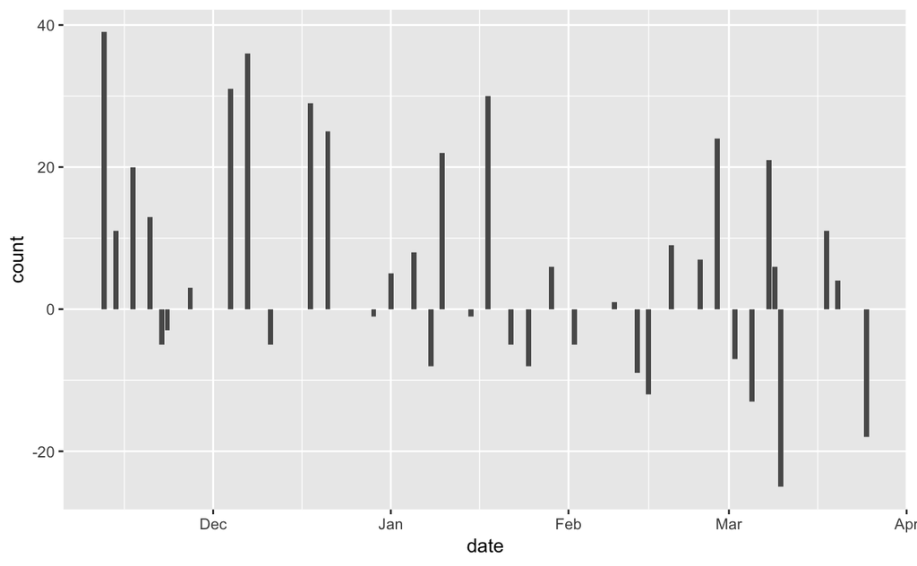

```r
ggplot() + geom_bar(data=arranged_logs, aes(date, weight=differential))
```

And now a look at the individual Marquette players for that season.

So Jae Crowder was my favorite player in 2010. So Let’s start off by plotting how many points he scored in each game throughout the season with `ggplot` in `tidyverse`

First, I need to remove the total points from Jae’s individual gamelog table since I only removed them in the combined mu_players dataframe.

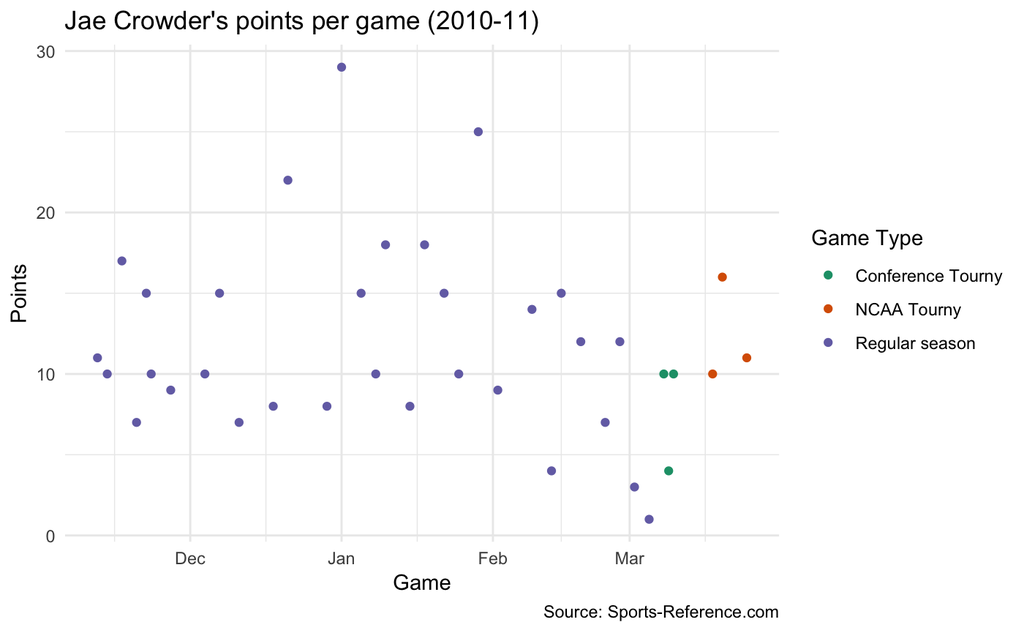

```r
# ymd() function uses "lubridate" package so load that library if needed.
jae_clean <- filter(crowder, !is.na(Rk)) %>% mutate(date = ymd(Date))
# now let's plot and add labels
jae_pts <- ggplot(jae_clean, aes(date, PTS)) +
  geom_point(aes(color = factor(Type))) +
  labs(title = "Jae Crowder's points per game (2010-11)", y = "Points", x = "Game", caption = "Source: Sports-Reference.com") +
  theme(axis.text.x = element_text(angle=45)) +
  # And let's fix the colors and legend
  scale_color_brewer(name = "Game Type", type = "qual", palette = "Dark2",
                               labels = c("Conference Tourny",
                                          "NCAA Tourny",
                                          "Regular season")) +
  theme_minimal()
jae_pts
```

How about all the players next to each other?

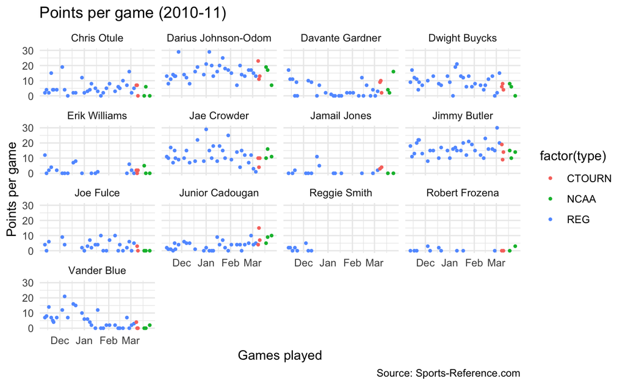

```r
# now let's plot and add labels
mu_players <- mutate(mu_players, date = ymd(date))
all_players <- ggplot(mu_players, aes(date, PTS)) +
  geom_point(aes(color = factor(type)), size = .8) +
  labs(title = "Points per game (2010-11)", y = "Points per game", x = "Games played", caption = "Source: Sports-Reference.com") +
  facet_wrap(~ player) +
  theme_minimal()
all_players
```

Now let’s step back and look at all NCAA teams 2018 season gamelogs as of the last week in February.

*This is where that first dataset from Matt Waite comes into play.*

Since we’ve been talking about Marquette let’s look at all team game logs and pull out just those in the Big East conference.

```r
all_teams %>% filter(Conference == "Big East") -> big_east
```

Let’s look at the field goal percentage across all Big East teams in the most recent 2018-19 season.

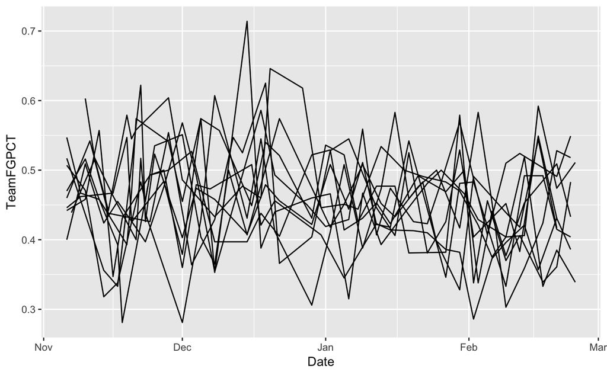

```r
ggplot() + geom_line(data=big_east, aes(x=Date, y=TeamFGPCT, group=Team))
```

That’s messy. Clean it up by highlighting specific teams and layering and setting styles.

We’ll create a new working dataframe with `grouped_by()` and create columns to highlight and total each team’s FG, FG attempts and a calculated FG percentage.

```r
big_east %>%
  group_by(Team) %>%
  summarize(
    season_attempts = sum(TeamFGA),
    season_fg = sum(TeamFG),
    season_pct = season_fg/season_attempts
  ) %>%
  arrange(desc(season_pct))
```

| Team | season_attempts | season_fg | season_pct |
| --- | --- | --- | --- |
| Creighton Bluejays | 1643 | 800 | 0.4869142 |
| Xavier Musketeers | 1559 | 730 | 0.4682489 |
| Marquette Golden Eagles | 1556 | 728 | 0.4678663 |
| DePaul Blue Demons | 1472 | 681 | 0.4626359 |
| St. John's (NY) Red Storm | 1724 | 787 | 0.4564965 |
| Butler Bulldogs | 1582 | 718 | 0.4538559 |
| Georgetown Hoyas | 1653 | 745 | 0.4506957 |
| Seton Hall Pirates | 1574 | 708 | 0.4498094 |
| Villanova Wildcats | 1583 | 702 | 0.4434618 |
| Providence Friars | 1637 | 683 | 0.4172266 |

Let’s compare Marquette to the team with the best season FG percentage, Creighton.

```r
mu <- big_east %>% filter(Team == "Marquette Golden Eagles")
cb <- big_east %>% filter(Team == "Creighton Bluejays")
```

And replot them with style:

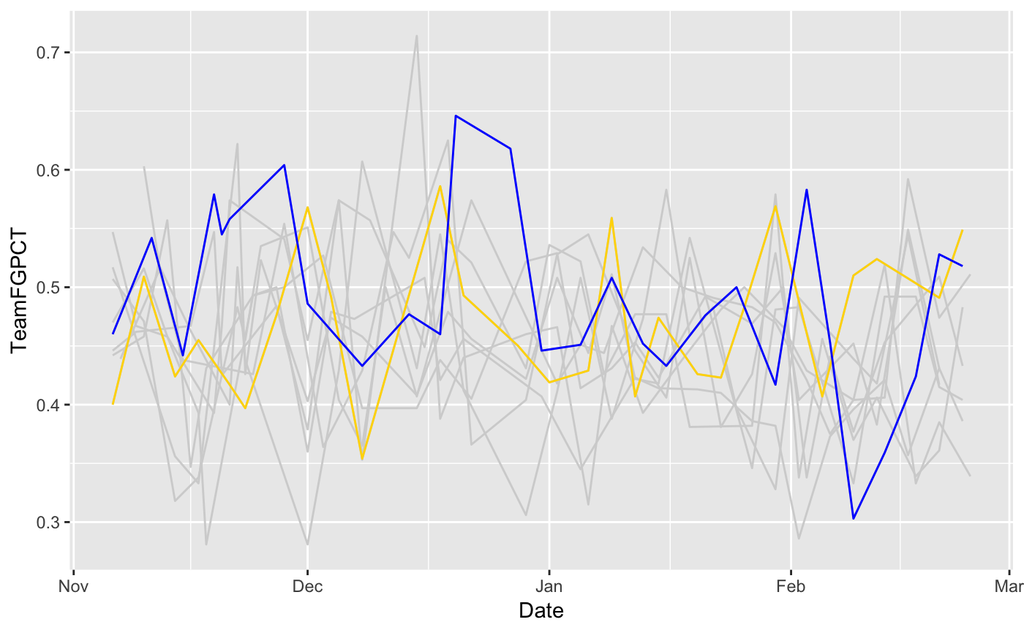

```r
ggplot() +
  geom_line(data=big_east, aes(x=Date, y=TeamFGPCT, group=Team), color="light grey") +
  geom_line(data=mu, aes(x=Date, y=TeamFGPCT, group=Team), color="gold") +
  geom_line(data=cb, aes(x=Date, y=TeamFGPCT, group=Team), color="blue")
```

Now we can see the teams but it’s hard to decipher who’s doing better just looking at the FG percentage.

How about getting more point differentials for those teams in the Big East like we did with just Marquette’s 2010-11 season gamelogs?

```r
big_east_tot <- big_east %>%
  mutate(differential = TeamScore-OpponentScore) %>%
  group_by(Team) %>%
  mutate(totaldifferential = cumsum(differential))
# let's just use Creighton and Marquette
muc <- big_east_tot %>% filter(Team == "Marquette Golden Eagles")
cbc <- big_east_tot %>% filter(Team == "Creighton Bluejays")
```

Let’s track cumulative change over time using a step chart. You’ll notice everything is about the same except we’ll use `geom_step` instead of `geom_line`

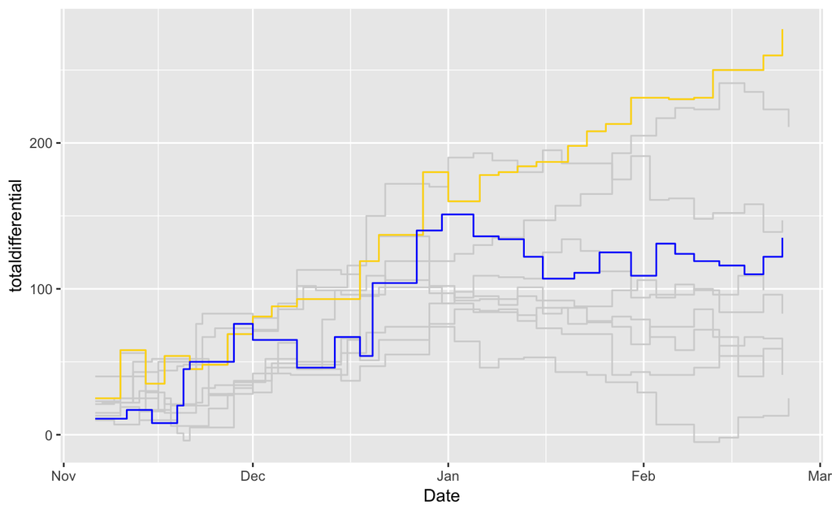

```r
ggplot() +
  geom_step(data=big_east_tot, aes(x=Date, y=totaldifferential, group=Team), color="light grey") +
  geom_step(data=muc, aes(x=Date, y=totaldifferential, group=Team), color="gold") +
  geom_step(data=cbc, aes(x=Date, y=totaldifferential, group=Team), color="blue")
```

You’ll see that even though Creighton had an overall better FG pecentage in the Big East Marquette still outpaces them in scoring differentials throughout the season.

### Finalize the grahpic

For better understanding let’s get some readable labels (`labs()`), source lines and a little cleaner style.

We’ll start by remaking the chart above:

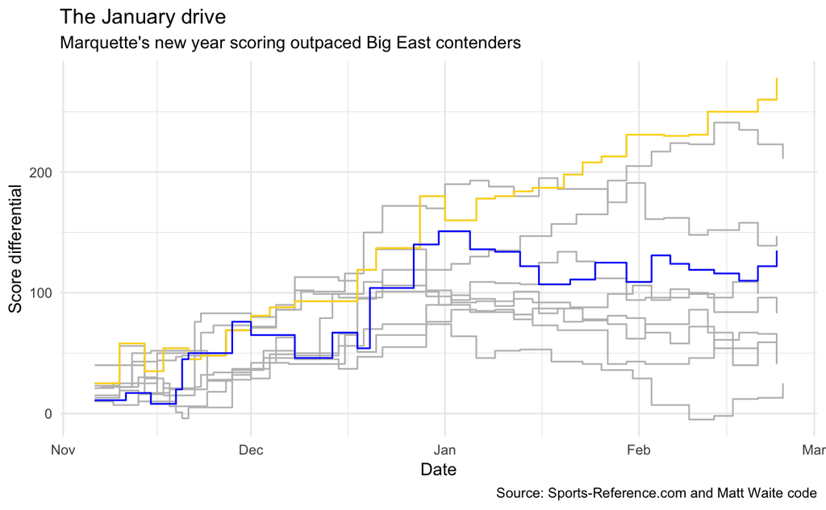

```r
final_plot <- ggplot() +
  geom_step(data=big_east_tot, aes(x=Date, y=totaldifferential, group=Team), color="grey") +
  geom_step(data=muc, aes(x=Date, y=totaldifferential, group=Team), color="gold") +
  geom_step(data=cbc, aes(x=Date, y=totaldifferential, group=Team), color="blue") +
  # and we'll add our labelling into the ggplot structure
  labs(x="Date", y="Score differential", title="The January drive", subtitle="Marquette's new year scoring outpaced Big East contenders", caption="Source: Sports-Reference.com and Matt Waite code") +
  theme(
    plot.title = element_text(size = 18, face = "bold"),
    plot.subtitle = element_text(size=10),
    axis.title.x = element_blank(),
    axis.text = element_text(size = 7),
    axis.ticks = element_blank()
  )
final_plot + theme_minimal()
```

## Export your work

`ggsave()` will export your most recently run chart in R.

Export filetype:

```r
#PDF
ggsave("players-plot.pdf", width = 7, height = 10, units = "in", dpi = 320)
ggsave("players-plot.png", width = 7, height = 10, units = "in", dpi = 320)
```